# DATA 621 Assignment 2

Joby John, Zachary Herold, Jun Pan

March 11, 2019

Set working environment

Load data

```r
output <- read.csv("https://raw.githubusercontent.com/johnpannyc/group-1-data-621-assignment-2/master/classification-output-data.csv")
```

1. DATA EXPLORATION

```r
glimpse(output)
```

```
## Observations: 181
## Variables: 11
## $ pregnant           <int> 7, 2, 3, 1, 4, 1, 9, 8, 1, 2, 5, 5, 13, 0, ...
## $ glucose            <int> 124, 122, 107, 91, 83, 100, 89, 120, 79, 12...
## $ diastolic          <int> 70, 76, 62, 64, 86, 74, 62, 78, 60, 48, 78,...
## $ skinfold           <int> 33, 27, 13, 24, 19, 12, 0, 0, 42, 32, 30, 4...
## $ insulin            <int> 215, 200, 48, 0, 0, 46, 0, 0, 48, 165, 0, 7...
## $ bmi                <dbl> 25.5, 35.9, 22.9, 29.2, 29.3, 19.5, 22.5, 2...
## $ pedigree           <dbl> 0.161, 0.483, 0.678, 0.192, 0.317, 0.149, 0...
## $ age                <int> 37, 26, 23, 21, 34, 28, 33, 64, 23, 26, 37,...
## $ class              <int> 0, 0, 1, 0, 0, 0, 0, 0, 0, 0, 0, 0, 0, 0, 1...
## $ scored.class       <int> 0, 0, 0, 0, 0, 0, 0, 0, 0, 0, 0, 0, 0, 0, 1...
## $ scored.probability <dbl> 0.32845226, 0.27319044, 0.10966039, 0.05599...
```

classification-output-data.csv file contains 181 observations of 11 variables. Three variables will be considered for this report - class (actual class for the observation), scored.class (predicted class for the observation), and scored.probability (predicted probability of success for the observation).

```r
summary(output)
```

```
##     pregnant         glucose        diastolic        skinfold
##  Min.   : 0.000   Min.   : 57.0   Min.   : 38.0   Min.   : 0.0
##  1st Qu.: 1.000   1st Qu.: 99.0   1st Qu.: 64.0   1st Qu.: 0.0
##  Median : 3.000   Median :112.0   Median : 70.0   Median :22.0
##  Mean   : 3.862   Mean   :118.3   Mean   : 71.7   Mean   :19.8
##  3rd Qu.: 6.000   3rd Qu.:136.0   3rd Qu.: 78.0   3rd Qu.:32.0
##  Max.   :15.000   Max.   :197.0   Max.   :104.0   Max.   :54.0
##     insulin            bmi           pedigree           age
##  Min.   :  0.00   Min.   :19.40   Min.   :0.0850   Min.   :21.00
##  1st Qu.:  0.00   1st Qu.:26.30   1st Qu.:0.2570   1st Qu.:24.00
##  Median :  0.00   Median :31.60   Median :0.3910   Median :30.00
##  Mean   : 63.77   Mean   :31.58   Mean   :0.4496   Mean   :33.31
##  3rd Qu.:105.00   3rd Qu.:36.00   3rd Qu.:0.5800   3rd Qu.:41.00
##  Max.   :543.00   Max.   :50.00   Max.   :2.2880   Max.   :67.00
##      class         scored.class    scored.probability
##  Min.   :0.0000   Min.   :0.0000   Min.   :0.02323
##  1st Qu.:0.0000   1st Qu.:0.0000   1st Qu.:0.11702
##  Median :0.0000   Median :0.0000   Median :0.23999
##  Mean   :0.3149   Mean   :0.1768   Mean   :0.30373
##  3rd Qu.:1.0000   3rd Qu.:0.0000   3rd Qu.:0.43093
##  Max.   :1.0000   Max.   :1.0000   Max.   :0.94633
```

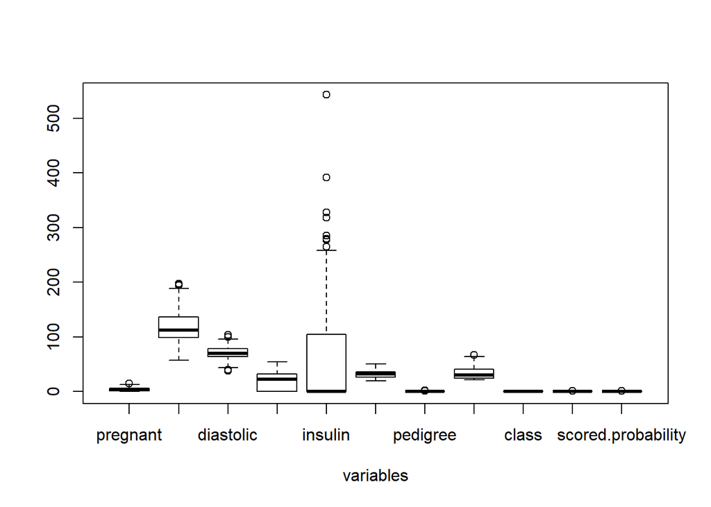

```r
boxplot(output,xlab="variables")
```

Check missing data

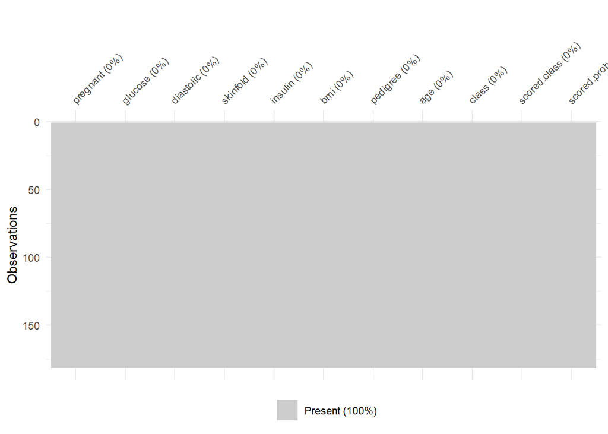

```r
vis_miss(output)
```

No missing data in the file.

Use the table() function to get the raw confusion matrix for this scored dataset (method 1)

```r
cf <- table(output[,9:10])
cf
```

```
##      scored.class
## class   0   1
##     0 119   5
##     1  30  27
```

Looking at the matrix above, rows represent actual class values of 0 or 1. Columns represent predicted class values of 0 or 1. So in the top left corner 119 is the number of observations where the class was correctly predicted to be 0. The top right corner shows 5 observations where the class of 0 was incorrectly predicted as 1. Similarly, we have 30 observations of class 1 incorrectedly predicted as class 0 and 27 observations of class 1 correctly predicted.

Use the table() function to get the raw confusion matrix for this scored dataset (method 2)

```r
data <- read.csv("https://raw.githubusercontent.com/johnpannyc/group-1-data-621-assignment-2/master/classification-output-data.csv")
cmatrix <-  table(data$class, data$scored.class)
cmatrix
```

```
##
##       0   1
##   0 119   5
##   1  30  27
```

```r
Accuracy <- function(df)
{
  names    = c("class", "scored.class")
  cmatrix  = table(df[, names])
  accuracy = (cmatrix[2,2] + cmatrix[1,1]) / (cmatrix[2,2] + cmatrix[1,2] + cmatrix[1,1] + cmatrix[2,1])
  return(round(accuracy, 2))
}
```

```r
Accuracy(output)
```

```
## [1] 0.81
```

```r
Classification_error_rate <- function(df)
{
  names    = c("class", "scored.class")
  cmatrix  = table(df[, names])
  classification_error_rate = (cmatrix[1,2] + cmatrix[2,1]) / (cmatrix[2,2] + cmatrix[1,2] + cmatrix[1,1] + cmatrix[2,1])
  return(round(classification_error_rate, 2))

}
```

```r
Classification_error_rate(output)
```

```
## [1] 0.19
```

```r
Precision <- function(df)
{
  names    = c("class", "scored.class")
  cmatrix  = table(df[, names])
  precision = (cmatrix[2,2] / (cmatrix[2,2] + cmatrix[1,2]))
  return(round(precision, 2))

}
```

```r
Precision(output)
```

```
## [1] 0.84
```

```r
Sensitivity <- function(df)
{
  names    = c("class", "scored.class")
  cmatrix  = table(df[, names])
  sensitivity = cmatrix[2,2] / (cmatrix[2,2] + cmatrix[2,1])
  return(round(sensitivity, 2))

}
```

```r
Sensitivity(output)
```

```
## [1] 0.47
```

```r
Specificity <- function(df)
{
  names    = c("class", "scored.class")
  cmatrix  = table(df[, names])
  specificity =  cmatrix[1,1] / (cmatrix[1,1] + cmatrix[1,2])
  return(round(specificity, 2))

}
```

```r
Specificity(output)
```

```
## [1] 0.96
```

```r
F1_Score <- function(df)
{
  names    = c("class", "scored.class")
  cmatrix  = table(df[, names])
  precision = Precision(df)
  sensitivity = Sensitivity(df)
  f1_score =  (2 * precision * sensitivity) /(precision + sensitivity)

  return(round(f1_score, 2))
}
```

```r
F1_Score(output)
```

```
## [1] 0.6
```

10.Manually create ROC curve

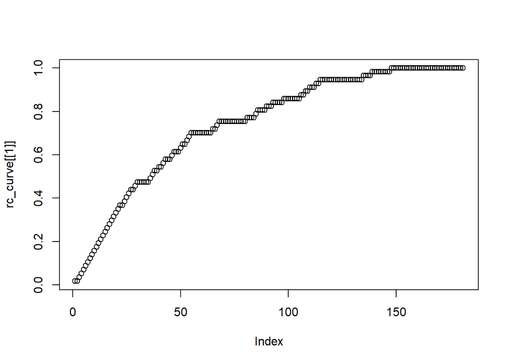

```r
manual_roc <- function(labels, scores){
  labels <- labels[order(scores, decreasing=TRUE)]
  TPR=cumsum(labels)/sum(labels)
  FPR=cumsum(!labels)/sum(!labels)
  df<- data.frame(TPR,FPR)
  dFPR <- c(diff(FPR), 0)
  dTPR <- c(diff(TPR), 0)
  auc <-sum(TPR * dFPR) + sum(dTPR * dFPR)/2
  return(c(df,auc))
}



rc_curve <- manual_roc(output$class,output$scored.probability)

plot(rc_curve[[1]])
```

```r
auc <- rc_curve[[2]]
```

## Q11 - Using the functions to generate the classification metrics

All metrics were provided as they were calculated. As we will see below using built-in functions makes life easier.

```r
Accuracy(output)
```

```
## [1] 0.81
```

```r
Classification_error_rate(output)
```

```
## [1] 0.19
```

```r
Precision(output)
```

```
## [1] 0.84
```

```r
Sensitivity(output)
```

```
## [1] 0.47
```

```r
Specificity(output)
```

```
## [1] 0.96
```

```r
F1_Score(output)
```

```
## [1] 0.6
```

## Q12 - Investigating the caret package

```r
if (!"caret" %in% installed.packages()) install.packages(caret)
require(caret)

ls(pos = "package:caret")
```

```
##   [1] "anovaScores"           "avNNet"
##   [3] "bag"                   "bagControl"
##   [5] "bagEarth"              "bagEarthStats"
##   [7] "bagFDA"                "best"
##   [9] "BoxCoxTrans"           "calibration"
##  [11] "caretFuncs"            "caretGA"
##  [13] "caretSA"               "caretSBF"
##  [15] "caretTheme"            "cforestStats"
##  [17] "checkConditionalX"     "checkInstall"
##  [19] "checkResamples"        "class2ind"
##  [21] "classDist"             "cluster"
##  [23] "compare_models"        "confusionMatrix"
##  [25] "confusionMatrix.train" "contr.dummy"
##  [27] "contr.ltfr"            "createDataPartition"
##  [29] "createFolds"           "createModel"
```

[output cut: 73 more lines]

```r
?sensitivity
```

```
## starting httpd help server ... done
```

```r
?confusionMatrix
?precision
```

## Transposing the table so that the actual referenced value (i.e., truth, “class”) is in columns, and the predicted measurement system (i.e. “scored.class”) is in rows

```r
df <- data[c("class","scored.class")]
cmatrix.t <- t(table(df))
cmatrix.t
```

```
##             class
## scored.class   0   1
##            0 119  30
##            1   5  27
```

```r
str(cmatrix.t)
```

```
##  'table' int [1:2, 1:2] 119 5 30 27
##  - attr(*, "dimnames")=List of 2
##   ..$ scored.class: chr [1:2] "0" "1"
##   ..$ class       : chr [1:2] "0" "1"
```

## Comparing the home-made functions and the caret package ones

```r
sens.caret <- round(sensitivity(cmatrix.t, positive = rownames(cmatrix)[2]),2)
sens.caret
```

```
## [1] 0.47
```

```r
identical(Sensitivity(data), sens.caret)
```

```
## [1] TRUE
```

```r
spec.caret <- round(specificity(cmatrix.t, negative = rownames(cmatrix)[1]),2)
spec.caret
```

```
## [1] 0.96
```

```r
identical(Specificity(data), spec.caret)
```

```
## [1] TRUE
```

```r
cMat.caret <- confusionMatrix(cmatrix.t, positive = "1")
cMat.caret
```

```
## Confusion Matrix and Statistics
##
##             class
## scored.class   0   1
##            0 119  30
##            1   5  27
##
##                Accuracy : 0.8066
##                  95% CI : (0.7415, 0.8615)
##     No Information Rate : 0.6851
##     P-Value [Acc > NIR] : 0.0001712
##
##                   Kappa : 0.4916
##  Mcnemar's Test P-Value : 4.976e-05
##
##             Sensitivity : 0.4737
##             Specificity : 0.9597
##          Pos Pred Value : 0.8438
##          Neg Pred Value : 0.7987
##              Prevalence : 0.3149
##          Detection Rate : 0.1492
##    Detection Prevalence : 0.1768
##       Balanced Accuracy : 0.7167
##
##        'Positive' Class : 1
##
```

```r
str(cMat.caret)
```

```
## List of 6
##  $ positive: chr "1"
##  $ table   : 'table' int [1:2, 1:2] 119 5 30 27
##   ..- attr(*, "dimnames")=List of 2
##   .. ..$ scored.class: chr [1:2] "0" "1"
##   .. ..$ class       : chr [1:2] "0" "1"
##  $ overall : Named num [1:7] 0.807 0.492 0.741 0.861 0.685 ...
##   ..- attr(*, "names")= chr [1:7] "Accuracy" "Kappa" "AccuracyLower" "AccuracyUpper" ...
##  $ byClass : Named num [1:11] 0.474 0.96 0.844 0.799 0.844 ...
##   ..- attr(*, "names")= chr [1:11] "Sensitivity" "Specificity" "Pos Pred Value" "Neg Pred Value" ...
##  $ mode    : chr "sens_spec"
##  $ dots    : list()
##  - attr(*, "class")= chr "confusionMatrix"
```

```r
prec.caret <- round(precision(cmatrix.t, relevant = "1"),2)
prec.caret
```

```
## [1] 0.84
```

```r
identical(Precision(data), prec.caret)
```

```
## [1] TRUE
```

```r
acc.caret <- round(cMat.caret$overall[1],2)
acc.caret
```

```
## Accuracy
##     0.81
```

```r
identical(Accuracy(data), acc.caret)  ## same value, but fail to match with identical function
```

```
## [1] FALSE
```

13. pROC Package Let us try the pROC package.

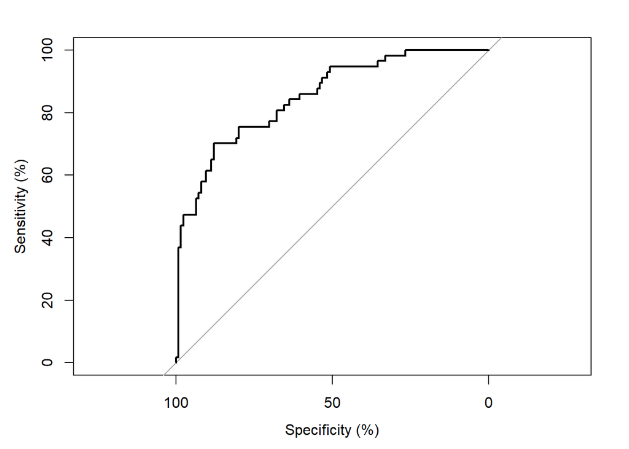

```
##
## Call:
## roc.default(response = output$class, predictor = output$scored.probability,     levels = c(0, 1), percent = TRUE, ci = TRUE, plot = TRUE)
##
## Data: output$scored.probability in 124 controls (output$class 0) < 57 cases (output$class 1).
## Area under the curve: 85.03%
## 95% CI: 79.05%-91.01% (DeLong)
```

```r
roc(output$class, output$scored.probability, levels=c(0,1), percent=TRUE, plot=TRUE, ci=TRUE)
```